# Global Library Imports

## Histogram Visualisation

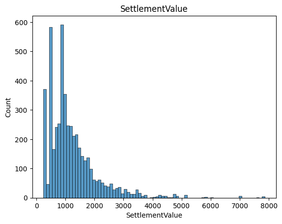

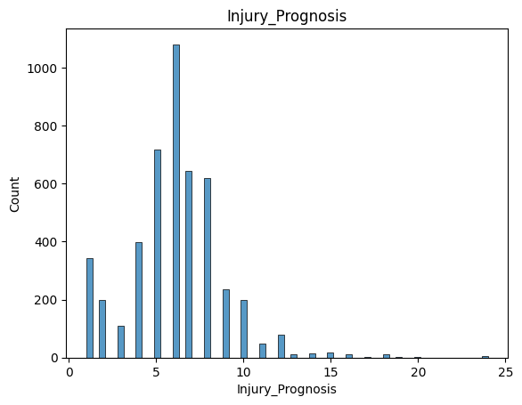

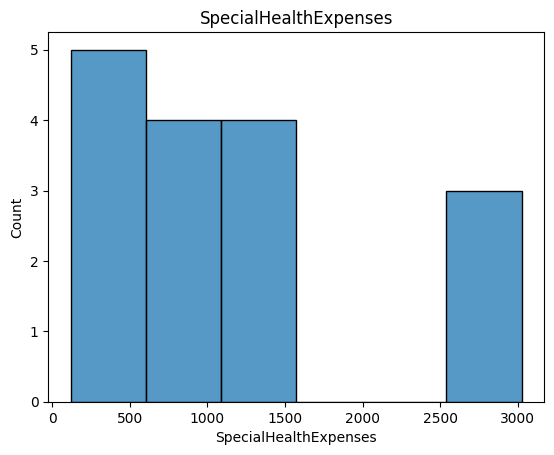

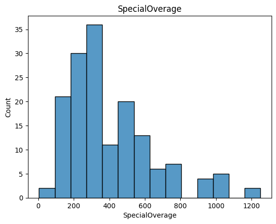

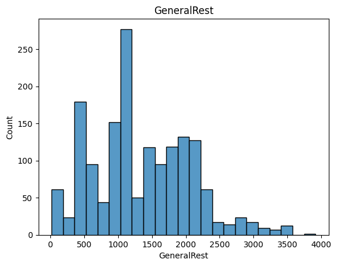

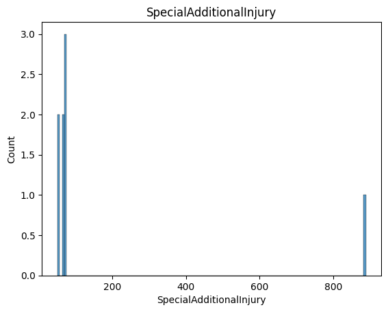

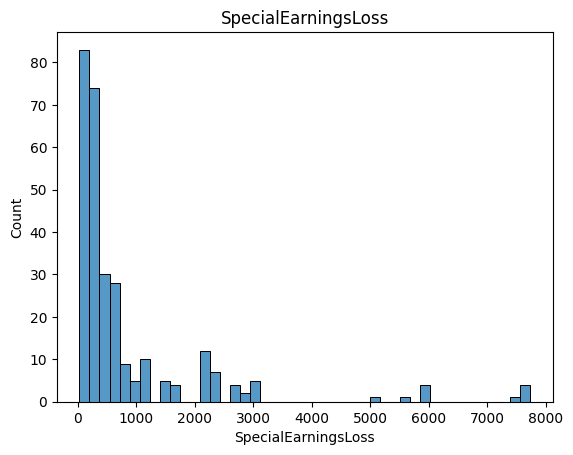

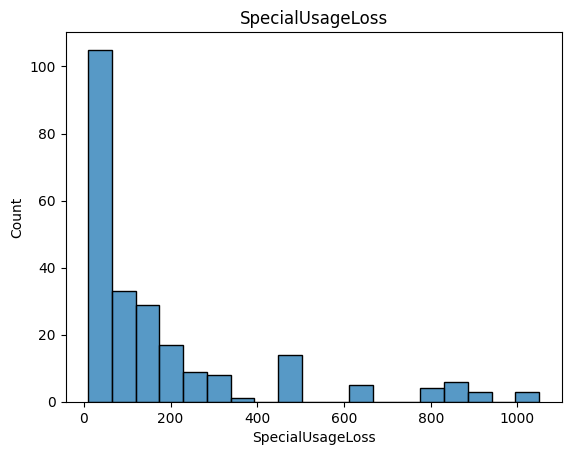

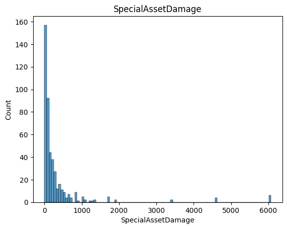

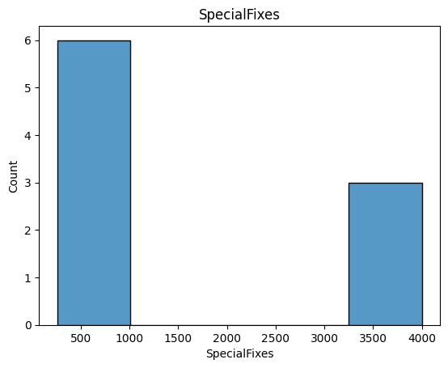

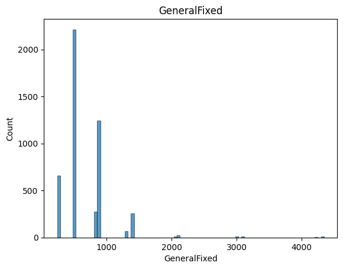

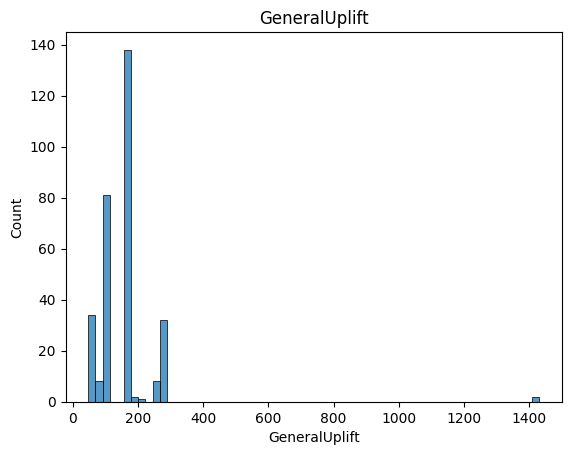

[4 more figures not shown]

```python
# display histogram of numerical columns plotting only non-zero values against the settlement column
for column in ml_dataset.select_dtypes(include='Int64'):
    sns.histplot(ml_dataset[ml_dataset[column] != 0][column])
    plt.title(column)
    plt.show()
```

## Display Null Value Counts

Null values indicate missing data and impact a feature column's usefulness in the training process

```python
# find nulls
ml_dataset.isnull().sum()
```

```
SettlementValue                 0
AccidentType                  111
Injury_Prognosis              146
SpecialHealthExpenses         117
SpecialOverage                109
GeneralRest                   119
SpecialAdditionalInjury       126
SpecialEarningsLoss           114
SpecialUsageLoss              121
SpecialAssetDamage            102
SpecialFixes                  112
GeneralFixed                  114
GeneralUplift                 126
SpecialLoanerVehicle          130
SpecialTripCosts              108
SpecialJourneyExpenses        136
SpecialTherapy                126
Exceptional_Circumstances      97
Minor_Psychological_Injury    107
Whiplash                      123
Police Report Filed             0
Witness Present                 0
dtype: int64
```

There are significant numbers of null values across the dataset, and most likely removing all of them would drastically reduce the number of rows, negatively impact model training. An approach is needed to identify which feature columns are correlated with the settlement value before determining how to proceed with NaN values in any column.

## Visualise correlations

```python
# import pandas as pd
# from sklearn.preprocessing import MinMaxScaler, StandardScaler

# def check_correlation(df, target_col, feature_col):
#     temp_df = df[[target_col, feature_col]]
#     temp_df = temp_df.dropna()

#     min_max_scaler = MinMaxScaler()
#     df[[target_col, feature_col]] = min_max_scaler.fit_transform(df[[target_col, feature_col]])

#     correlation = temp_df[target_col].corr(df[feature_col])
#     if correlation > 0.5 or correlation < -0.5:
#         print(f'Correlation between {target_col} and {feature_col}: {correlation}')
#     elif correlation > 0.95 or correlation < -0.95:
#         print(f'Redundant Correlation between {target_col} and {feature_col}: {correlation}')
#     else:
#         print(f'Correlation between {target_col} and {feature_col} not statistically significant: {correlation}')
```

```python
ml_dataset.head()
```

|  | SettlementValue | AccidentType | Injury_Prognosis | SpecialHealthExpenses | SpecialOverage | GeneralRest | SpecialAdditionalInjury | SpecialEarningsLoss | SpecialUsageLoss | SpecialAssetDamage | ... | GeneralUplift | SpecialLoanerVehicle | SpecialTripCosts | SpecialJourneyExpenses | SpecialTherapy | Exceptional_Circumstances | Minor_Psychological_Injury | Whiplash | Police Report Filed | Witness Present |
| --- | --- | --- | --- | --- | --- | --- | --- | --- | --- | --- | --- | --- | --- | --- | --- | --- | --- | --- | --- | --- | --- |
| 0 | 520 | Rear end | 5 | 0 | 0 | 0 | 0 | 0 | 0 | 0 | ... | 0 | 0 | 0 | 0 | 0 | No | Yes | Yes | Yes | Yes |
| 1 | 870 | Rear end | 2 | 0 | 0 | 520 | 0 | 0 | 90 | 0 | ... | 0 | 0 | 0 | 0 | 0 | No | Yes | Yes | Yes | Yes |
| 2 | 2140 | Other side pulled out of side road | 7 | 0 | 0 | 1400 | 0 | 0 | 0 | 0 | ... | 0 | 0 | 0 | 0 | 0 | No | No | Yes | Yes | No |
| 3 | 520 | Rear end - Clt pushed into next vehicle | 4 | 0 | 0 | 0 | 0 | 0 | 0 | 0 | ... | 0 | 0 | 0 | 0 | 0 | No | Yes | Yes | Yes | Yes |
| 4 | 260 | Rear end | 3 | 0 | 0 | 0 | 0 | 0 | 0 | 0 | ... | 0 | 0 | 0 | 0 | 0 | No | Yes | No | Yes | Yes |

5 rows × 22 columns

```python
for column in ml_dataset:
    if column != 'SettlementValue' and ml_dataset[column].dtype != 'object':
            for column2 in ml_dataset:
                if column2 != (column or 'SettlementValue') and ml_dataset[column2].dtype != 'object':
                    check_correlation(ml_dataset, column, column2)
```

[output not shown]

## Convert simple binary columns

Columns to convert:

Exceptional_Circumstances, Minor_Psychological_Injury, Whiplash, Police Report Filed, Witness Present

```python
binary_cols = ['Exceptional_Circumstances', 'Minor_Psychological_Injury', 'Whiplash', 'Police Report Filed', 'Witness Present']
for col in binary_cols:
    ml_dataset = binary_encode(ml_dataset, col, 'Yes')
```

[output not shown]

```python
ml_dataset.head(50)
```

[output not shown]

```python
# for column in ml_dataset.select_dtypes(include=[object]):
#     ml_dataset[column] = ml_dataset[column].fillna('No')
```

```python
for column in ml_dataset.select_dtypes(include='Int64'):
    ml_dataset[column] = ml_dataset[column].fillna(0)
```

```python
ml_dataset.isnull().sum()
```

```
SettlementValue                 0
AccidentType                  111
Injury_Prognosis                0
SpecialHealthExpenses           0
SpecialOverage                  0
GeneralRest                     0
SpecialAdditionalInjury         0
SpecialEarningsLoss             0
SpecialUsageLoss                0
SpecialAssetDamage              0
SpecialFixes                    0
GeneralFixed                    0
GeneralUplift                   0
SpecialLoanerVehicle            0
SpecialTripCosts                0
SpecialJourneyExpenses          0
SpecialTherapy                  0
Exceptional_Circumstances      97
Minor_Psychological_Injury    107
Whiplash                      123
Police Report Filed             0
Witness Present                 0
dtype: int64
```

```python
# import pandas as pd
# import numpy as np
# from sklearn.compose import ColumnTransformer
# from sklearn.pipeline import Pipeline
# from sklearn.impute import SimpleImputer
# from sklearn.preprocessing import StandardScaler, OneHotEncoder
# from sklearn.feature_selection import mutual_info_regression, SelectKBest, RFE
# from sklearn.linear_model import LinearRegression
# from statsmodels.stats.outliers_influence import variance_inflation_factor
# import seaborn as sns
# import matplotlib.pyplot as plt
# import scipy.sparse as sparse
# from tqdm import tqdm
# from time import time
# import sys

# def log(message):
#     print(f"[{time():.1f}] {message}")
#     sys.stdout.flush()

# # Load dataset
# log("Initializing pipeline...")
# df = pd.read_csv('./Synthetic_Data_For_Students.csv')
# y = df['SettlementValue']
# X = df.drop('SettlementValue', axis=1)

# # Identify column types
# numerical_cols = X.select_dtypes(include=np.number).columns.tolist()
# categorical_cols = X.select_dtypes(include=['object']).columns.tolist()

# # Configure preprocessing with name preservation
# preprocessor = ColumnTransformer(
#     transformers=[
#         ('num', Pipeline(steps=[
#             ('imputer', SimpleImputer(strategy='median')),
#             ('scaler', StandardScaler())
#         ]), numerical_cols),
#         ('cat', Pipeline(steps=[
#             ('imputer', SimpleImputer(strategy='most_frequent')),
#             ('encoder', OneHotEncoder(
#                 handle_unknown='ignore',
#                 sparse_output=True,
#                 feature_name_combiner=lambda feature, category: f"{feature}_{category}"
#             ))
#         ]), categorical_cols)
#     ],
#     verbose_feature_names_out=False,
#     remainder='drop'
# )

# # Feature selection pipeline with validated dimensions
# feature_selector = Pipeline([
#     ('preprocessor', preprocessor),
#     ('kbest', SelectKBest(score_func=mutual_info_regression, k=15)),
#     ('rfe', RFE(LinearRegression(), n_features_to_select=10))
# ])

# def analyze_features(X_transformed, feature_names):
#     log("Starting feature analysis")

#     # Convert to dense array with NaN handling
#     if sparse.issparse(X_transformed):
#         log("Converting sparse matrix to dense...")
#         X_dense = X_transformed.astype(float).toarray()
#     else:
#         X_dense = X_transformed.astype(float)

#     df = pd.DataFrame(X_dense, columns=feature_names)

#     # Handle remaining NaNs
#     nan_count = df.isna().sum().sum()
#     if nan_count > 0:
#         log(f"Imputing {nan_count} NaN values...")
#         df = pd.DataFrame(SimpleImputer(strategy='median').fit_transform(df),
#                          columns=feature_names)

#     # Remove zero-variance features
#     valid_features = df.columns[df.nunique() > 1].tolist()
#     df = df[valid_features]

#     # Correlation analysis
#     log("Calculating correlations...")
#     corr_matrix = df.corr()
#     plt.figure(figsize=(12,10))
#     sns.heatmap(corr_matrix, annot=False, cmap='coolwarm')
#     plt.title('Feature Correlation Matrix')
#     plt.show()

#     # VIF calculation with progress
#     log("Calculating VIF scores...")
#     vif_data = pd.DataFrame({'feature': valid_features})
#     vif_values = []

#     for i in tqdm(range(len(valid_features)), desc="VIF Calculation"):
#         try:
#             vif = variance_inflation_factor(df.values.astype(float), i)
#             vif_values.append(vif)
#         except Exception as e:
#             log(f"Error in {valid_features[i]}: {str(e)}")
#             vif_values.append(np.nan)

#     vif_data['VIF'] = vif_values
#     print("VIF Results:\n", vif_data.sort_values('VIF', ascending=False))

# # Execute preprocessing
# log("Preprocessing data...")
# X_preprocessed = preprocessor.fit_transform(X)

# # Generate valid feature names
# feature_names = (
#     numerical_cols +
#     preprocessor.named_transformers_['cat']
#     .named_steps['encoder']
#     .get_feature_names_out(categorical_cols).tolist()
# )

# # Feature analysis
# log("Performing feature analysis...")
# analyze_features(X_preprocessed, feature_names)

# # Mutual information with enhanced NaN handling
# log("Preparing for mutual information...")
# if y.isna().any():
#     log("Imputing target variable...")
#     y = y.fillna(y.median())

# X_mi = X_preprocessed.astype(float)
# if sparse.issparse(X_mi):
#     X_mi = X_mi.toarray()

# if np.isnan(X_mi).any():
#     log("Cleaning feature NaNs...")
#     X_mi = SimpleImputer(strategy='median').fit_transform(X_mi)

# log("Calculating mutual information...")
# mi_scores = mutual_info_regression(X_mi, y, random_state=42, n_jobs=-1)
# mi_df = pd.DataFrame({'feature': feature_names, 'mi_score': mi_scores}) \
#          .sort_values('mi_score', ascending=False)
# plt.figure(figsize=(10,6))
# sns.barplot(x='mi_score', y='feature', data=mi_df.head(15))
# plt.title('Top Features by Mutual Information')
# plt.show()

# # Feature selection execution
# log("Starting feature selection...")
# feature_selector.fit(X, y)

# # Get final features with validated names
# log("Resolving feature names...")
# preprocessed_features = (
#     numerical_cols +
#     preprocessor.named_transformers_['cat']
#     .named_steps['encoder']
#     .get_feature_names_out(categorical_cols).tolist()
# )

# selected_features = feature_selector.named_steps['kbest'] \
#     .get_feature_names_out(input_features=preprocessed_features)

# final_features = feature_selector.named_steps['rfe'] \
#     .get_feature_names_out(input_features=selected_features)

# print("\nFinal Selected Features:")
# print(pd.DataFrame(final_features, columns=['Features']))

# # Generate processed dataset
# log("Creating final dataset...")
# X_processed = pd.DataFrame(
#     feature_selector.transform(X),
#     columns=final_features
# )

# log("Pipeline execution completed successfully.")
```

```python
def calculate_feature_relevance(df):
    def log(message):
        print(f"[{time():.1f}] {message}")
        sys.stdout.flush()

    y = df['SettlementValue']
    X = df.drop(['SettlementValue'], axis=1)

    # Identify column types
    numerical_cols = X.select_dtypes(include=np.number).columns.tolist()
    categorical_cols = X.select_dtypes(include=['object']).columns.tolist()

    # Preprocessing pipeline
    preprocessor = ColumnTransformer(transformers=[
        ('num', Pipeline(steps=[
            ('imputer', SimpleImputer(strategy='median')),
            ('scaler', StandardScaler())
        ]), numerical_cols),
        ('cat', Pipeline(steps=[
            ('imputer', SimpleImputer(strategy='most_frequent')),
            ('encoder', OneHotEncoder(handle_unknown='ignore', sparse_output=True, max_categories=10))
        ]), categorical_cols)
    ])

    # Feature selection pipeline
    # Feature selection pipeline
    feature_selector = Pipeline(steps=[
        ('preprocessor', preprocessor),
        ('feature_selection', SelectKBest(score_func=mutual_info_regression, k=15))
        # RFE removed as it was causing feature name mismatches
    ])
    def analyze_features(X_transformed, feature_names):
        log("Starting feature analysis")

        # Conversion to dense array
        start_time = time()
        if sparse.issparse(X_transformed):
            log("Converting sparse matrix to dense array...")
            X_dense = X_transformed.toarray()
            df = pd.DataFrame(X_dense, columns=feature_names)
        else:
            log("Using existing dense matrix...")
            df = pd.DataFrame(X_transformed, columns=feature_names)
        log(f"DataFrame shape after conversion: {df.shape} (took {time()-start_time:.1f}s)")

        # Remove zero-variance features
        start_time = time()
        log("Checking for zero-variance features...")
        df = df.loc[:, df.nunique() > 1]
        valid_features = df.columns.tolist()
        log(f"Removed {len(feature_names)-len(valid_features)} constant features (took {time()-start_time:.1f}s)")

        # Correlation matrix
        if len(valid_features) > 0:
            log("Calculating correlation matrix...")
            start_time = time()
            corr_matrix = df.corr()
            log(f"Correlation matrix calculated (took {time()-start_time:.1f}s)")

            log("Plotting heatmap...")
            plt.figure(figsize=(12,10))
            sns.heatmap(corr_matrix, annot=False, cmap='coolwarm')
            plt.title('Feature Correlation Matrix')
            plt.show()
            log("Heatmap displayed")
        else:
            print("No valid features for correlation analysis")
            return

        # VIF calculation
        log("Starting VIF calculations...")
        vif_data = pd.DataFrame()
        vif_data["feature"] = valid_features
        vif_values = []

        start_time = time()
        for i in tqdm(range(len(valid_features)), desc="VIF Progress"):
            try:
                vif = variance_inflation_factor(df.values.astype(float), i)
                vif_values.append(vif)
            except Exception as e:
                log(f"Error calculating VIF for {valid_features[i]}: {str(e)}")
                vif_values.append(np.nan)

        log(f"Completed VIF calculations (took {time()-start_time:.1f}s)")
        vif_data["VIF"] = vif_values
        print("Variance Inflation Factors:\n", vif_data.sort_values('VIF', ascending=False))

    # Execute pipeline
    log("Starting preprocessing pipeline...")
    start_time = time()
    X_preprocessed = preprocessor.fit_transform(X)
    log(f"Preprocessing completed (took {time()-start_time:.1f}s)")

    log("Building feature names...")
    feature_names = numerical_cols.copy()
    try:
        cat_features = preprocessor.named_transformers_['cat']\
                    .named_steps['encoder']\
                    .get_feature_names_out(categorical_cols).tolist()
        feature_names += cat_features
        log(f"Added {len(cat_features)} categorical features")
    except Exception as e:
        log(f"Error getting categorical features: {str(e)}")

    log(f"Total features after preprocessing: {len(feature_names)}")

    # Feature relationship analysis
    log("Starting feature analysis...")
    analyze_features(X_preprocessed, feature_names)

    # Mutual information scores
    # Modify the mutual information calculation section as follows:

    # Mutual information scores
    log("Checking for NaNs in target variable...")
    if y.isna().any():
        log(f"Found {y.isna().sum()} NaN values in target variable 'y', imputing with median...")
        y = y.fillna(y.median())
        log("Target variable NaN handling completed")

    log("Verifying preprocessed data...")
    if sparse.issparse(X_preprocessed):
        X_dense_mi = X_preprocessed.astype(float).toarray()
    else:
        X_dense_mi = X_preprocessed.astype(float)

    if np.isnan(X_dense_mi).any():
        log("Found NaN in preprocessed features, imputing...")
        from sklearn.impute import SimpleImputer
        X_dense_mi = SimpleImputer(strategy='median').fit_transform(X_dense_mi)
        log("Feature matrix NaN handling completed")

    log("Calculating mutual information scores...")
    start_time = time()
    with np.errstate(divide='ignore', invalid='ignore'):
        mi_scores = mutual_info_regression(
            X_dense_mi,
            y,
            random_state=42,
            n_jobs=-1
        )
    log(f"Mutual info calculated (took {time()-start_time:.1f}s)")


    mi_df = pd.DataFrame({'feature': feature_names, 'mi_score': mi_scores}) \
            .sort_values('mi_score', ascending=False)
    plt.figure(figsize=(10,6))
    sns.barplot(x='mi_score', y='feature', data=mi_df.head(15))
    plt.title('Top Features by Mutual Information')
    plt.show()

    # Feature selection
    # Feature selection
    log("Starting feature selection pipeline...")
    start_time = time()

    log("Fit preprocessing and SelectKBest...")
    feature_selector.fit(X, y)  # Fit the entire pipeline
    log("Completed feature selection")

    log(f"Feature selection completed (total time {time()-start_time:.1f}s)")

    # Get the feature names directly from the fitted pipeline
    try:
        # Get the feature names after preprocessing
        preprocessed_features = feature_selector.named_steps['preprocessor'].get_feature_names_out()

        # Get the selected features
        selected_mask = feature_selector.named_steps['feature_selection'].get_support()
        final_features = preprocessed_features[selected_mask]

        print(f"Selected features: {final_features}")
    except Exception as e:
        log(f"Error getting feature names: {str(e)}")
        # Fallback method if the above fails
    # Get processed dataframe
    X_processed = pd.DataFrame(
        feature_selector.transform(X),
        columns=final_features
    )

    # Display the first few rows of the processed dataframe
    print("\nProcessed dataframe preview:")
    print(X_processed.head())
    X_processed = pd.DataFrame(feature_selector.transform(X),
                            columns=final_features)

    log("Analysis complete.")

    # train a simple xgboost model and visualize the feature importances
    import xgboost as xgb
    from xgboost import plot_importance

    # train the model
    model = xgb.XGBRegressor()
    model.fit(X_processed, y)

    # plot the feature importances
    plot_importance(model)
    plt.show()

    # display the feature importance scores
    feature_importances = model.feature_importances_
    feature_importances_df = pd.DataFrame({'feature': final_features, 'importance': feature_importances})
    feature_importances_df = feature_importances_df.sort_values('importance', ascending=False)
    print(feature_importances_df)

    # display the top 10 most important features
    plt.figure(figsize=(10,6))
    sns.barplot(x='importance', y='feature', data=feature_importances_df.head(10))
    plt.title('Top 10 Features by Importance')
    plt.show()

    # split the data into training and test sets
    X_train, X_test, y_train, y_test = train_test_split(X_processed, y, test_size=0.2, random_state=42)

    # train the model
    model = xgb.XGBRegressor()
    model.fit(X_train, y_train)

    # make predictions
    y_pred = model.predict(X_test)

    # calculate the mean squared error
    rmse = root_mean_squared_error(y_test, y_pred)
    print("Root Mean Squared Error:", rmse)
```

```python
# train a simple xgboost model and visualize the feature importances
import xgboost as xgb
from xgboost import plot_importance

# train the model
model = xgb.XGBRegressor()
model.fit(X_processed, y)

# plot the feature importances
plot_importance(model)
plt.show()

# display the feature importance scores
feature_importances = model.feature_importances_
feature_importances_df = pd.DataFrame({'feature': final_features, 'importance': feature_importances})
feature_importances_df = feature_importances_df.sort_values('importance', ascending=False)
print(feature_importances_df)

# display the top 10 most important features
plt.figure(figsize=(10,6))
sns.barplot(x='importance', y='feature', data=feature_importances_df.head(10))
plt.title('Top 10 Features by Importance')
plt.show()
```

[output not shown]

```python
# split the data into training and test sets
X_train, X_test, y_train, y_test = train_test_split(X_processed, y, test_size=0.2, random_state=42)

# train the model
model = xgb.XGBRegressor()
model.fit(X_train, y_train)

# make predictions
y_pred = model.predict(X_test)

# calculate the mean squared error
rmse = root_mean_squared_error(y_test, y_pred)
print("Root Mean Squared Error:", rmse)
```

[output not shown]

## Display count of zero values for all columns

Zero values are often used as placeholders for null values, so any row containing a zero value should be validated to determine if it is appropriate.

```python
X_processed.head()
```

[output not shown]

```python
# train simple linear regression model to predict settlement value
from sklearn.model_selection import train_test_split
from sklearn.metrics import mean_squared_error

X_train, X_test, y_train, y_test = train_test_split(X_processed, y, test_size=0.2, random_state=42)

model = LinearRegression()
model.fit(X_train, y_train)
y_pred = model.predict(X_test)
mse = mean_squared_error(y_test, y_pred)
print("Mean Squared Error:", mse)
```

[output not shown]

```python
# Count number of zeros in all columns of Dataframe
for column_name in ml_dataset.columns:
    column = ml_dataset[column_name]
    # Get the count of Zeros in column
    count = (column == 0).sum()
    print('Count of zeros in column ', column_name, ' is : ', count)
```

[output not shown]

## Impute Missing Values

```python
# display describe summary table to confirm the changes
ml_dataset.describe()
```

|  | SettlementValue | Injury_Prognosis | SpecialHealthExpenses | SpecialOverage | GeneralRest | SpecialAdditionalInjury | SpecialEarningsLoss | SpecialUsageLoss | SpecialAssetDamage | SpecialFixes | GeneralFixed | GeneralUplift | SpecialLoanerVehicle | SpecialTripCosts | SpecialJourneyExpenses | SpecialTherapy |
| --- | --- | --- | --- | --- | --- | --- | --- | --- | --- | --- | --- | --- | --- | --- | --- | --- |
| count | 4894.0 | 4894.0 | 4894.0 | 4894.0 | 4894.0 | 4894.0 | 4894.0 | 4894.0 | 4894.0 | 4894.0 | 4894.0 | 4894.0 | 4894.0 | 4894.0 | 4894.0 | 4894.0 |
| mean | 1218.011034 | 5.923376 | 3.593993 | 13.170208 | 451.347364 | 0.271761 | 50.232938 | 8.896608 | 32.8396 | 3.112996 | 671.276052 | 10.184307 | 7.641398 | 1.907029 | 11.406825 | 179.824888 |
| std | 858.868374 | 2.903878 | 84.839385 | 83.834612 | 760.895472 | 12.931461 | 387.558177 | 65.14246 | 282.054489 | 101.135089 | 408.396521 | 49.739879 | 140.667883 | 12.902983 | 48.767325 | 223.313352 |
| min | 240.0 | 0.0 | 0.0 | 0.0 | 0.0 | 0.0 | 0.0 | 0.0 | 0.0 | 0.0 | 0.0 | 0.0 | 0.0 | 0.0 | 0.0 | 0.0 |
| 25% | 669.0 | 5.0 | 0.0 | 0.0 | 0.0 | 0.0 | 0.0 | 0.0 | 0.0 | 0.0 | 495.0 | 0.0 | 0.0 | 0.0 | 0.0 | 0.0 |
| 50% | 988.0 | 6.0 | 0.0 | 0.0 | 0.0 | 0.0 | 0.0 | 0.0 | 0.0 | 0.0 | 520.0 | 0.0 | 0.0 | 0.0 | 0.0 | 50.0 |
| 75% | 1510.0 | 8.0 | 0.0 | 0.0 | 880.0 | 0.0 | 0.0 | 0.0 | 0.0 | 0.0 | 895.0 | 0.0 | 0.0 | 0.0 | 0.0 | 350.0 |
| max | 7863.0 | 24.0 | 3024.0 | 1250.0 | 3913.0 | 889.0 | 7736.0 | 1050.0 | 6070.0 | 4000.0 | 4345.0 | 1430.0 | 4408.0 | 254.0 | 880.0 | 1225.0 |

### Impute mean average

```python
# # replace NaN values with mean value for the SkinThickness column
# ml_dataset["SkinThickness"] = ml_dataset["SkinThickness"].fillna((ml_dataset["SkinThickness"].mean())).round(2)

# # display column summary to confirm changes
# ml_dataset["SkinThickness"].describe()
```

### Impute using KNN

```python
# from sklearn.impute import KNNImputer

# # create a KNN imputer object
# imputer = KNNImputer(n_neighbors=5)

# # impute missing values using KNN for specified columns
# columns = ['Glucose','BloodPressure','BMI']
# for col in columns:
#     temp_df = pd.DataFrame(ml_dataset[col])
#     ml_dataset[col] = pd.DataFrame(imputer.fit_transform(temp_df)).round(2)

# ml_dataset.describe()
```

# Model 1: Baseline for Comparison

## Split Features and Classifications

Split the dataset into two ndarrays, one for the feature matrix and another for the corresponding classifications.

```python
# # Create X for features
# X=df.drop(['Settlement'],axis=1)

# # Create y for classes
# y=df['Settlement']

# # Display first 5 rows of X
# X[:5]
```

## Divide Train and Test

```python
# from sklearn.model_selection import train_test_split
# X_train, X_test, y_train, y_test = train_test_split(X,y,test_size=0.3,random_state=1)

# print('Training dataframes have shape:', X_train.shape, y_train.shape, '\nTest dataframes have shape:',X_test.shape, y_test.shape)
```

## Stratification

```python
## split dataframe using stratification
# train, test = train_test_split(ml_dataset_4col, test_size=0.3, random_state=1, stratify=ml_dataset_4col['Outcome'])

## split stratified training data into features and classes
# X_train=train.drop(['Outcome'],axis=1)
# y_train=train['Outcome']

## split stratified test data into features and classes
# X_test=test.drop(['Outcome'],axis=1)
# y_test=test['Outcome']
```

## Display Train and Test dataframes

```python
# def display_head(display):
#     if display == 'X_train':
#         print(X_train.head(5))

#     if display == 'X_test':
#         print(X_test.head(5))

#     if display == 'y_train':
#         print(y_train.head(5))

#     if display == 'y_test':
#         print(y_test.head(5))

# widgets.interact(lambda Selection: display_head(Selection), Selection=['X_train', 'y_train', 'X_test', 'y_test'])
```

## Create Processing and Training Pipeline

```python
# # Import libraries required for SVM model, pipeline and scaling
# from sklearn.pipeline import Pipeline
# from sklearn.preprocessing import StandardScaler
# from sklearn.svm import SVC

# # create pipeline to scale features
# default_pipe = Pipeline(steps=[('scaler', StandardScaler()), ('svm', SVC())])
```

## Train Default Model

```python
# # import libraries required for reporting
# from sklearn import metrics

# # train default model using the pipeline
# default_pipe.fit(X_train, y_train)

# # make predictions based on the default model
# y_pred_def = default_pipe.predict(X_test)
```

## Performance Metrics Function

As we will be re-using these performance metrics throughout the notebook, it makes sense to create a function that can be called as needed.

```python
# # import library functions
# from sklearn.metrics import classification_report

# def display_metrics(y_test,y_pred):
#     # generate and display confusion matrix
#     conf_matrix = confusion_matrix(y_test,y_pred)
#     plot_confusion_matrix(conf_matrix)

#     # display classification report
#     print(classification_report(y_test,y_pred))

#     # display f1 score
#     print('F1 Score:', f1_score(y_test,y_pred))

#     # display roc-auc score
#     print('ROC-AUC Score:', roc_auc_score(y_test,y_pred))
```

## Default Model Performance Metrics Report

```python
# # display metrics using previously defined function
# display_metrics(y_test,y_pred_def)
```

## Apply Class Weighting

```python
# # create weighted pipeline to scale features
# weighted_pipe = Pipeline(steps=[('scaler', StandardScaler()), ('svm', SVC(class_weight='balanced'))])

# # train model using the weighted pipeline
# weighted_pipe.fit(X_train, y_train)

# # make predictions based on the weighted model
# y_pred_weighted = weighted_pipe.predict(X_test)

# # display metrics using previously defined function
# display_metrics(y_test,y_pred_weighted)
```

## Cross Validation

Rather than just training the model once on the entire training dataset, cross validation partitions the data into multiple subsets, training the model on some subsets and validating it on others, and then averaging the results to better estimate its performance on unseen data, resulting in a more generalized model with reduced tendency to overfit.

The sklearn RepeatedStratifiedKFold function is a cross-validation method that implements stratification of the training and validation partitions during cross validation. It achieves this by repeatedly splitting the dataset into 'K' stratified folds, ensuring that each fold is a good representative of the whole, and it is used multiple times to provide a more robust estimate of model performance.

```python
# # importing libraries and functions needed for cross validation
# from sklearn.model_selection import cross_val_score
# from sklearn.model_selection import RepeatedStratifiedKFold

# # define reusable cross validation test harness
# cv = RepeatedStratifiedKFold(n_splits=10, n_repeats=3, random_state=1)
```